# Home Credit Modeling

Xinyuan Chen, Sterling LeDuc, Robby Stohel

2025-03-16

# Introduction

In this project, my team and I are tackling the challenge of assessing loan default risk using a dataset provided by a Kaggle competition. Our objective is to build a predictive model that can accurately determine the likelihood of loan default based on a variety of features, such as demographic and financial information. To achieve this, we will follow a structured approach that includes thorough data cleaning, feature engineering, and model selection. By experimenting with different modeling techniques, we aim to develop a model that not only performs well on training data but also generalizes effectively to unseen data, ultimately providing valuable insights into the risk of loan defaults.

This model has the potential to solve Home Credit Group’s business problem by helping them make smarter, more informed lending decisions. Home Credit provides financial services to individuals without a traditional credit history, making it difficult to assess their ability to repay loans. By predicting applicants’ repayment ability, this model will enable more accurate lending decisions, reducing the risk of defaults and preventing the rejection of creditworthy applicants.

### Helper Functions

In this section, we implemented a series of data cleaning functions based on the rules determined during our exploratory data analysis (EDA). These rules focus on standardizing variable formats, handling missing values, and addressing potential imbalances in the dataset. Here’s a summary of the changes made by each function:

- **`order_columns`**: Reorders the columns of the dataframe alphabetically for consistency.
- **`quick_clean`**:
  - Converts character columns with specific values (“N”, “Y”, ““) into factors with labels”No” and “Yes.”
  - Ensures consistent factor levels for character columns with values “Yes” and “No.”
  - Converts numeric columns with values 0 and 1 into factors labeled “No” and “Yes.”
  - Applies factor conversion to all character columns, skipping any specified in the `skip_columns` argument.
  - Replaces missing values (NA) in numeric columns with 0.0. However, additional imputations are performed below on some numeric predictors where defaulting to 0.0 didn’t make sense (e.g., predictors with specific patterns or meaningful values) to ensure better handling of missing data.
- **`filter_low_variability`**:
  - Filters out columns with high missing percentages or imbalance, based on a threshold (default 50%). The function calculates the percentage of missing values, zeros, or the most frequent value for each column and removes those with high variability.
- **`validate_imbalances`**:
  - Summarizes column imbalances, including missing value percentages, zero percentages, and the most frequent value’s percentage. It calculates a combined “sum percentage” for numeric columns (missing + zero) and provides this summary to identify problematic columns.
- **`match_factor_levels`**: Ensures that factor levels in the dataset match those in a full reference dataset, maintaining consistency across factor variables.

These functions will be applied to clean and standardize the data before further analysis and model development.

```r
# Function to order columns alphabetically in a dataframe
order_columns <- function(df) {
  df[, order(names(df))]
}

# Initial cleaning function based on exploratory data analysis (EDA)
quick_clean <- function(df, skip_columns = c()) {
  return(df %>%
    order_columns() %>%
    mutate_if(
      is.character,
      function(x) if (all(unique(x) %in% c("N", "Y", "")))
        factor(ifelse(x == "Y", "Yes", "No"), levels = c("No", "Yes"))
      else x
    ) %>%
    mutate_if(
      is.character,
      function(x) if (all(unique(x) %in% c("Yes", "No", "")))
        factor(x, levels = c("No", "Yes"))
      else x
    ) %>%
    mutate_if(
      is.numeric,
      function(x) if (all(na.omit(unique(x)) %in% c(0, 1)))
        factor(ifelse(x == 1, "Yes", "No"), levels = c("No", "Yes"))
      else x
    ) %>%
    mutate(across(where(is.character) & !any_of(skip_columns), ~ factor(.))) %>%
    mutate(across(where(~ is.numeric(.) | is.integer(.)), ~ replace_na(., 0.0))))
}

# Function to remove columns with high missing percentages or imbalances
filter_low_variability <- function(df, threshold = 50, exclude_col = NULL, filter_column = "sum_percentage") {
  # Identify columns to process (excluding the specified column)
  cols_to_check <- setdiff(names(df), exclude_col)

  # Initialize a vector to store variability percentages
  total_perc <- rep(0, length(cols_to_check))
  names(total_perc) <- cols_to_check

  # Loop through each column to calculate its imbalance and missing values
  for (col in cols_to_check) {
    column_data <- df[[col]]

    if (is.factor(column_data) || is.character(column_data)) {
      # For factor or character columns: Calculate percentage of most frequent value
      value_counts <- table(column_data, useNA = "ifany")
      value_perc <- (value_counts / length(column_data)) * 100
      total_perc[col] <- max(value_perc)

    } else if (is.numeric(column_data)) {
      # For numeric columns: Calculate percentage of missing and zero values
      missing_perc <- sum(is.na(column_data)) / length(column_data) * 100
      zero_perc <- sum(column_data == 0, na.rm = TRUE) / length(column_data) * 100
      total_perc[col] <- missing_perc + zero_perc
    }
  }

  # Filter columns based on the threshold (default is sum_percentage)
  cols_to_keep <- names(total_perc[total_perc < threshold])

  # If we need to filter on a specific column percentage, apply that filter
  if (filter_column != "sum_percentage") {
    cols_to_keep <- names(total_perc[total_perc < threshold & total_perc[filter_column] < threshold])
  }

  # Ensure the excluded column is included in the final dataset if it exists
  final_cols <- unique(c(cols_to_keep, exclude_col))

  return(df[, final_cols, drop = FALSE])
}

# Function to validate and summarize column imbalances (missing values, zeros, etc.)
validate_imbalances <- function(df, threshold = 50, exclude_col = NULL) {
  # Identify columns to process (excluding the specified column)
  cols_to_check <- setdiff(names(df), exclude_col)

  # Initialize a dataframe to store imbalance summary
  imbalance_summary <- data.frame(
    column = character(0),
    missing_percentage = numeric(0),
    zero_percentage = numeric(0),
    most_frequent_value = character(0),
    most_frequent_percentage = numeric(0),
    sum_percentage = numeric(0),  # New column for the sum
    stringsAsFactors = FALSE
  )

  # Loop through each column to calculate imbalances and proportions
  for (col in cols_to_check) {
    column_data <- df[[col]]

    if (is.factor(column_data) || is.character(column_data)) {
      # For factor or character columns: Calculate imbalance of unique values
      value_counts <- table(column_data, useNA = "ifany")
      value_perc <- round((value_counts / length(column_data)) * 100, 2)

      # Find most frequent value and its percentage
      most_frequent_value <- names(value_perc)[which.max(value_perc)]
      most_frequent_percentage <- max(value_perc)

      # Add imbalance information to the summary
      imbalance_summary <- rbind(imbalance_summary,
        data.frame(
          column = col,
          missing_percentage = NA, # Not applicable for factor columns
          zero_percentage = NA,    # Not applicable for factor columns
          most_frequent_value = most_frequent_value,
          most_frequent_percentage = most_frequent_percentage,
          sum_percentage = most_frequent_percentage # Only include most frequent percentage
        )
      )

    } else if (is.numeric(column_data)) {
      # For numeric columns: Calculate missing and zero percentages
      missing_perc <- round(sum(is.na(column_data)) / length(column_data) * 100, 2)
      zero_perc <- round(sum(column_data == 0, na.rm = TRUE) / length(column_data) * 100, 2)

      # Calculate sum of missing and zero percentages
      sum_percentage <- missing_perc + zero_perc

      # Add imbalance information to the summary
      imbalance_summary <- rbind(imbalance_summary,
        data.frame(
          column = col,
          missing_percentage = missing_perc,
          zero_percentage = zero_perc,
          most_frequent_value = NA,  # Not applicable for numeric columns
          most_frequent_percentage = NA,
          sum_percentage = sum_percentage # Sum missing and zero percentages
        )
      )
    }
  }

  # Sort the imbalance summary by sum_percentage in descending order
  imbalance_summary <- imbalance_summary[order(-imbalance_summary$sum_percentage), ]

  # Convert column names to snake_case
  names(imbalance_summary) <- gsub("([a-z])([A-Z])", "\\1_\\2", names(imbalance_summary)) # Add underscore before uppercase letters
  names(imbalance_summary) <- tolower(names(imbalance_summary)) # Convert all to lowercase

  # Return the imbalance summary
  return(imbalance_summary)
}

# Function to match factor levels between data and full dataset
match_factor_levels <- function(data, full_data) {
  data %>%
    mutate(across(where(is.factor), ~ factor(., levels = levels(full_data[[cur_column()]]))))
}
```

# Prohibited Factors for Loan Decisions

Lending regulations across various countries prohibit the use of certain personal data when making loan decisions to prevent discrimination. The following list aggregates restricted factors from the *United States, Czech Republic, Slovakia, Kazakhstan, China, Vietnam, Air Bank (Czech Republic), India, Indonesia, and the Philippines* **as these locations were listed as areas of operation for Home Credit based on their website**. These regions have laws and regulations that generally prohibit discrimination based on attributes such as race, ethnicity, religion, gender, age, disability, and social status. Below is a combined and de-duplicated list of factors that cannot legally be used to determine loan eligibility, or for our purposes, default risk.

- **Race**
- **Ethnicity**
- **Religion or belief**
- **Gender**
- **Age (unless related to contract capacity)**
- **Disability**
- **Marital status**
- **Nationality or place of birth**
- **Social status or caste**
- **Receipt of public assistance**
- **Language**
- **Political beliefs**
- **Familial status (in housing-related loans)**
- **Exercising consumer protection rights**

This list provides a broad overview of anti-discrimination factors applicable across multiple jurisdictions. However, specific regulations may vary by country. Using illegal factors in lending decisions can result in lawsuits, regulatory penalties, and reputation damage. As such, we have started by removing potential predictors from our the dataset that could pose future legal concerns for the client.

```r
train <- train %>%
  select(
    -CODE_GENDER,
    -CNT_CHILDREN,
    -NAME_FAMILY_STATUS,
    -DAYS_BIRTH,
    -DAYS_EMPLOYED,
    -CNT_FAM_MEMBERS
  )
```

# Initial Data Cleaning

```r
# Function to handle missing values by imputing them with appropriate values
app_imputation <- function(df) {
  df %>%
    mutate(
      APARTMENTS_AVG = replace_na(APARTMENTS_AVG, median(APARTMENTS_AVG, na.rm = TRUE)),
      APARTMENTS_MEDI = replace_na(APARTMENTS_MEDI, median(APARTMENTS_MEDI, na.rm = TRUE)),
      APARTMENTS_MODE = replace_na(APARTMENTS_MODE, median(APARTMENTS_MODE, na.rm = TRUE)),
      BASEMENTAREA_AVG = replace_na(BASEMENTAREA_AVG, median(BASEMENTAREA_AVG, na.rm = TRUE)),
      BASEMENTAREA_MEDI = replace_na(BASEMENTAREA_MEDI, median(BASEMENTAREA_MEDI, na.rm = TRUE)),
      BASEMENTAREA_MODE = replace_na(BASEMENTAREA_MODE, median(BASEMENTAREA_MODE, na.rm = TRUE)),
      COMMONAREA_AVG = replace_na(COMMONAREA_AVG, median(COMMONAREA_AVG, na.rm = TRUE)),
      COMMONAREA_MEDI = replace_na(COMMONAREA_MEDI, median(COMMONAREA_MEDI, na.rm = TRUE)),
      ENTRANCES_AVG = replace_na(ENTRANCES_AVG, median(ENTRANCES_AVG, na.rm = TRUE)),
      ENTRANCES_MEDI = replace_na(ENTRANCES_MEDI, median(ENTRANCES_MEDI, na.rm = TRUE)),
      ENTRANCES_MODE = replace_na(ENTRANCES_MODE, median(ENTRANCES_MODE, na.rm = TRUE)),
      FLOORSMAX_AVG = replace_na(FLOORSMAX_AVG, median(FLOORSMAX_AVG, na.rm = TRUE)),
      FLOORSMAX_MEDI = replace_na(FLOORSMAX_MEDI, median(FLOORSMAX_MEDI, na.rm = TRUE)),
      FLOORSMAX_MODE = replace_na(FLOORSMAX_MODE, median(FLOORSMAX_MODE, na.rm = TRUE)),
      FLOORSMIN_AVG = replace_na(FLOORSMIN_AVG, median(FLOORSMIN_AVG, na.rm = TRUE)),
      FLOORSMIN_MEDI = replace_na(FLOORSMIN_MEDI, median(FLOORSMIN_MEDI, na.rm = TRUE)),
      FLOORSMIN_MODE = replace_na(FLOORSMIN_MODE, median(FLOORSMIN_MODE, na.rm = TRUE)),
      LANDAREA_AVG = replace_na(LANDAREA_AVG, median(LANDAREA_AVG, na.rm = TRUE)),
      LANDAREA_MEDI = replace_na(LANDAREA_MEDI, median(LANDAREA_MEDI, na.rm = TRUE)),
      LANDAREA_MODE = replace_na(LANDAREA_MODE, median(LANDAREA_MODE, na.rm = TRUE)),
      LIVINGAPARTMENTS_AVG = replace_na(LIVINGAPARTMENTS_AVG, median(LIVINGAPARTMENTS_AVG, na.rm = TRUE)),
      LIVINGAPARTMENTS_MEDI = replace_na(LIVINGAPARTMENTS_MEDI, median(LIVINGAPARTMENTS_MEDI, na.rm = TRUE)),
      LIVINGAPARTMENTS_MODE = replace_na(LIVINGAPARTMENTS_MODE, median(LIVINGAPARTMENTS_MODE, na.rm = TRUE)),
      LIVINGAREA_AVG = replace_na(LIVINGAREA_AVG, median(LIVINGAREA_AVG, na.rm = TRUE)),
      LIVINGAREA_MEDI = replace_na(LIVINGAREA_MEDI, median(LIVINGAREA_MEDI, na.rm = TRUE)),
      LIVINGAREA_MODE = replace_na(LIVINGAREA_MODE, median(LIVINGAREA_MODE, na.rm = TRUE)),
      NONLIVINGAPARTMENTS_AVG = replace_na(NONLIVINGAPARTMENTS_AVG, median(NONLIVINGAPARTMENTS_AVG, na.rm = TRUE)),
      NONLIVINGAPARTMENTS_MEDI = replace_na(NONLIVINGAPARTMENTS_MEDI, median(NONLIVINGAPARTMENTS_MEDI, na.rm = TRUE)),
      NONLIVINGAPARTMENTS_MODE = replace_na(NONLIVINGAPARTMENTS_MODE, median(NONLIVINGAPARTMENTS_MODE, na.rm = TRUE)),
      NONLIVINGAREA_AVG = replace_na(NONLIVINGAREA_AVG, median(NONLIVINGAREA_AVG, na.rm = TRUE)),
      NONLIVINGAREA_MEDI = replace_na(NONLIVINGAREA_MEDI, median(NONLIVINGAREA_MEDI, na.rm = TRUE)),
      NONLIVINGAREA_MODE = replace_na(NONLIVINGAREA_MODE, median(NONLIVINGAREA_MODE, na.rm = TRUE)),
      TOTALAREA_MODE = replace_na(TOTALAREA_MODE, median(TOTALAREA_MODE, na.rm = TRUE)),
      YEARS_BEGINEXPLUATATION_AVG = replace_na(YEARS_BEGINEXPLUATATION_AVG, median(YEARS_BEGINEXPLUATATION_AVG, na.rm = TRUE)),
      YEARS_BEGINEXPLUATATION_MEDI = replace_na(YEARS_BEGINEXPLUATATION_MEDI, median(YEARS_BEGINEXPLUATATION_MEDI, na.rm = TRUE)),
      YEARS_BEGINEXPLUATATION_MODE = replace_na(YEARS_BEGINEXPLUATATION_MODE, median(YEARS_BEGINEXPLUATATION_MODE, na.rm = TRUE)),
      YEARS_BUILD_AVG = replace_na(YEARS_BUILD_AVG, median(YEARS_BUILD_AVG, na.rm = TRUE)),
      YEARS_BUILD_MEDI = replace_na(YEARS_BUILD_MEDI, median(YEARS_BUILD_MEDI, na.rm = TRUE)),
      YEARS_BUILD_MODE = replace_na(YEARS_BUILD_MODE, median(YEARS_BUILD_MODE, na.rm = TRUE)),
      EMERGENCYSTATE_MODE = ifelse(
        "EMERGENCYSTATE_MODE" %in% colnames(df),
        replace_na(
          EMERGENCYSTATE_MODE,
          names(sort(table(EMERGENCYSTATE_MODE), decreasing = TRUE))[1]
        ),
        EMERGENCYSTATE_MODE
      )
    )
}

# Apply imputation function and clean the data for training set
train <- train %>%
  app_imputation() %>%
  quick_clean()

# Apply imputation function and clean the data for testing set
test <- test %>%
  app_imputation() %>%
  quick_clean()
```

# Feature Engineering

```r
# Aggregate the bureau dataset to count active credit records per SK_ID_CURR
bureau_agg <- read.csv("bureau.csv") %>%
  quick_clean() %>%
  group_by(SK_ID_CURR) %>%
  summarise(
    CREDIT_ACTIVE_COUNT = n(),
    CREDIT_DAY_OVERDUE_SUM = sum(CREDIT_DAY_OVERDUE),  # Commented as 99% of values were 0
    AMT_CREDIT_SUM_DEBT_SUM = sum(AMT_CREDIT_SUM_DEBT),
    AMT_CREDIT_SUM_OVERDUE_SUM = sum(AMT_CREDIT_SUM_OVERDUE),
    CREDIT_OVERDUE_MAX = max(CREDIT_DAY_OVERDUE)  # Commented as 99% of values were 0
  )

# Aggregate the previous_application dataset to count total applications
# and calculate the average credit amount per SK_ID_CURR
previous_application_agg <- read.csv("previous_application.csv") %>%
  mutate(NAME_TYPE_SUITE = replace_na(data = NAME_TYPE_SUITE, replace = "Unaccompanied")) %>%
  quick_clean() %>%
  group_by(SK_ID_CURR) %>%
  summarise(
    PREVIOUS_APPLICATIONS_COUNT = n(),
    AMT_ANNUITY_SUM = sum(AMT_ANNUITY),
    AMT_APPLICATION_SUM = sum(AMT_APPLICATION),
    AMT_CREDIT_SUM = sum(AMT_CREDIT),
    AMT_DOWN_PAYMENT_SUM = sum(AMT_DOWN_PAYMENT),
    AMT_GOODS_PRICE_SUM = sum(AMT_GOODS_PRICE),
    RATE_DOWN_PAYMENT_SUM = sum(RATE_DOWN_PAYMENT),
    CNT_PAYMENT_SUM = sum(CNT_PAYMENT),
    RATE_INTEREST_PRIMARY_AVG = mean(RATE_INTEREST_PRIMARY),
    AMT_CREDIT_AVG = mean(AMT_CREDIT)
  )

# Aggregate the pos_cash_balance dataset to calculate the average months balance per SK_ID_CURR
pos_cash_balance_agg <- read.csv("POS_CASH_balance.csv") %>%
  quick_clean() %>%
  group_by(SK_ID_CURR) %>%
  summarise(
    CNT_INSTALMENT_FUTURE_SUM = sum(CNT_INSTALMENT_FUTURE),
    SK_DPD_SUM = sum(SK_DPD),
    MONTHS_BALANCE_AVG = mean(MONTHS_BALANCE)
  )

# Aggregate the credit_card_balance dataset to calculate the average balance per SK_ID_CURR
credit_card_balance_agg <- read.csv("credit_card_balance.csv") %>%
  quick_clean() %>%
  group_by(SK_ID_CURR) %>%
  summarise(
    AMT_DRAWINGS_ATM_CURRENT_SUM = sum(AMT_DRAWINGS_ATM_CURRENT),
    AMT_DRAWINGS_OTHER_CURRENT_SUM = sum(AMT_DRAWINGS_OTHER_CURRENT),
    AMT_DRAWINGS_POS_CURRENT_SUM = sum(AMT_DRAWINGS_POS_CURRENT),
    AMT_PAYMENT_CURRENT_SUM = sum(AMT_PAYMENT_CURRENT),
    CNT_DRAWINGS_ATM_CURRENT_SUM = sum(CNT_DRAWINGS_ATM_CURRENT),
    CNT_DRAWINGS_OTHER_CURRENT_SUM = sum(CNT_DRAWINGS_OTHER_CURRENT),
    CNT_DRAWINGS_POS_CURRENT_SUM = sum(CNT_DRAWINGS_POS_CURRENT),
    CNT_INSTALMENT_MATURE_CUM_SUM = sum(CNT_INSTALMENT_MATURE_CUM),
    AMT_BALANCE_AVG = mean(AMT_BALANCE)
  )

# Aggregate the installments_payments dataset to calculate the average days installment per SK_ID_CURR
installments_payments_agg <- read.csv("installments_payments.csv") %>%
  quick_clean() %>%
  mutate(
    DAYS_LATE = DAYS_INSTALMENT - DAYS_ENTRY_PAYMENT,
    PAYMENT_DIFFERENCE = AMT_INSTALMENT - AMT_PAYMENT
  ) %>%
  group_by(SK_ID_CURR) %>%
  summarise(
    DAYS_INSTALMENT_AVG = mean(DAYS_INSTALMENT),
    DAYS_LATE_AVG = mean(DAYS_LATE),
    PAYMENT_DIFFERENCE_AVG = mean(PAYMENT_DIFFERENCE)
  )
```

In this section, we aggregated data from several datasets to summarize key financial metrics per applicant (SK_ID_CURR). We cleaned the data using the `quick_clean` function and performed grouping by `SK_ID_CURR` to calculate various summary statistics, such as sums, averages, and counts for different financial indicators. For example, we aggregated data related to credit records, previous applications, POS cash balances, credit card balances, and installment payments. Some variables were further modified, like replacing missing values in certain columns, and we handled specific calculations such as days late and payment differences. This aggregation process helped create a more manageable dataset for further analysis and modeling. Next, we will join these aggregated datasets to our main train and test datasets to integrate these features for our predictive model.

```r
# Merge into Main Train Data
train <- train %>%
  left_join(bureau_agg, by = "SK_ID_CURR") %>%
  left_join(previous_application_agg, by = "SK_ID_CURR") %>%
  left_join(pos_cash_balance_agg, by = "SK_ID_CURR") %>%
  left_join(credit_card_balance_agg, by = "SK_ID_CURR") %>%
  left_join(installments_payments_agg, by = "SK_ID_CURR")

## Merge into Main Test Data
test <- test %>%
  left_join(bureau_agg, by = "SK_ID_CURR") %>%
  left_join(previous_application_agg, by = "SK_ID_CURR") %>%
  left_join(pos_cash_balance_agg, by = "SK_ID_CURR") %>%
  left_join(credit_card_balance_agg, by = "SK_ID_CURR") %>%
  left_join(installments_payments_agg, by = "SK_ID_CURR")

# Re-clean na values as the preceding left merge will introduce more
# Including low variability column filtering here as well
train <- train %>%
  quick_clean() %>%
  filter_low_variability(exclude_col = "TARGET", threshold = 91)

test <- test %>%
  quick_clean()

validate_imbalances(train)
```

```
##                            column missing_percentage zero_percentage
## 109                        TARGET                 NA              NA
## 75             NAME_CONTRACT_TYPE                 NA              NA
## 11   AMT_DRAWINGS_POS_CURRENT_SUM                  0           88.88
## 26   CNT_DRAWINGS_POS_CURRENT_SUM                  0           88.88
## 77              NAME_HOUSING_TYPE                 NA              NA
## 82       NONLIVINGAPARTMENTS_MODE                  0           88.70
## 39       DEF_30_CNT_SOCIAL_CIRCLE                  0           88.56
## 81       NONLIVINGAPARTMENTS_MEDI                  0           87.68
## 80        NONLIVINGAPARTMENTS_AVG                  0           87.17
## 16      AMT_REQ_CREDIT_BUREAU_MON                  0           85.77
## 17      AMT_REQ_CREDIT_BUREAU_QRT                  0           83.55
## 10   AMT_DRAWINGS_ATM_CURRENT_SUM                  0           83.32
## 25   CNT_DRAWINGS_ATM_CURRENT_SUM                  0           83.32
## 42                 ELEVATORS_MODE                  0           82.40
```

[output cut: 205 more lines]

```r
# Ensure both sets have the same features (beside TARGET on the training set)
common_features <- intersect(names(train), names(test))
train <- train[, c(common_features, "TARGET")]
test <- test[, common_features]
```

In this code, we first clean the training and test datasets by addressing missing values using the `quick_clean` function. For the training set, we also filter out columns with low variability (excluding the “TARGET” column) based on a threshold of 91%. Then, we validate any class imbalances in the training data with the `validate_imbalances` function. Finally, we ensure that both the training and test datasets have the same features by selecting the common columns and aligning them, while retaining the “TARGET” column in the training set.

# Post-Cleaning Data Evaluation

Here we perform a few post-cleaning validations on the dataset. We checks for any remaining missing values and provides a general summary of the data using `skim()`. Additionally, we scale our numerical predictors in preparation for modeling, excluding the `SK_ID_CURR` column, which is not relevant for the transformation. This step ensures the data is appropriately prepped for subsequent model building.

```r
# Skim through the training dataset to get a summary of the variables
skim(train)
```

Data summary

| Name | train |
| --- | --- |
| Number of rows | 307511 |
| Number of columns | 109 |
| _______________________ |  |
| Column type frequency: |  |
| factor | 20 |
| numeric | 89 |
| ________________________ |  |
| Group variables | None |

**Variable type: factor**

| skim_variable | n_missing | complete_rate | ordered | n_unique | top_counts |
| --- | --- | --- | --- | --- | --- |
| FLAG_DOCUMENT_3 | 0 | 1 | FALSE | 2 | Yes: 218340, No: 89171 |
| FLAG_EMP_PHONE | 0 | 1 | FALSE | 2 | Yes: 252125, No: 55386 |
| FLAG_OWN_CAR | 0 | 1 | FALSE | 2 | No: 202924, Yes: 104587 |
| FLAG_OWN_REALTY | 0 | 1 | FALSE | 2 | Yes: 213312, No: 94199 |
| FLAG_PHONE | 0 | 1 | FALSE | 2 | No: 221080, Yes: 86431 |
| FLAG_WORK_PHONE | 0 | 1 | FALSE | 2 | No: 246203, Yes: 61308 |
| FONDKAPREMONT_MODE | 0 | 1 | FALSE | 5 | emp: 210295, reg: 73830, reg: 12080, not: 5687 |
| HOUSETYPE_MODE | 0 | 1 | FALSE | 4 | emp: 154297, blo: 150503, spe: 1499, ter: 1212 |
| LIVE_CITY_NOT_WORK_CITY | 0 | 1 | FALSE | 2 | No: 252296, Yes: 55215 |
| NAME_CONTRACT_TYPE | 0 | 1 | FALSE | 2 | Cas: 278232, Rev: 29279 |
| NAME_EDUCATION_TYPE | 0 | 1 | FALSE | 5 | Sec: 218391, Hig: 74863, Inc: 10277, Low: 3816 |
| NAME_HOUSING_TYPE | 0 | 1 | FALSE | 6 | Hou: 272868, Wit: 14840, Mun: 11183, Ren: 4881 |
| NAME_INCOME_TYPE | 0 | 1 | FALSE | 8 | Wor: 158774, Com: 71617, Pen: 55362, Sta: 21703 |
| NAME_TYPE_SUITE | 0 | 1 | FALSE | 8 | Una: 248526, Fam: 40149, Spo: 11370, Chi: 3267 |
| OCCUPATION_TYPE | 0 | 1 | FALSE | 19 | emp: 96391, Lab: 55186, Sal: 32102, Cor: 27570 |
| ORGANIZATION_TYPE | 0 | 1 | FALSE | 58 | Bus: 67992, XNA: 55374, Sel: 38412, Oth: 16683 |
| REG_CITY_NOT_WORK_CITY | 0 | 1 | FALSE | 2 | No: 236644, Yes: 70867 |
| WALLSMATERIAL_MODE | 0 | 1 | FALSE | 8 | emp: 156341, Pan: 66040, Sto: 64815, Blo: 9253 |
| WEEKDAY_APPR_PROCESS_START | 0 | 1 | FALSE | 7 | TUE: 53901, WED: 51934, MON: 50714, THU: 50591 |
| TARGET | 0 | 1 | FALSE | 2 | No: 282686, Yes: 24825 |

**Variable type: numeric**

| skim_variable | n_missing | complete_rate | mean | sd | p0 | p25 | p50 | p75 | p100 | hist |
| --- | --- | --- | --- | --- | --- | --- | --- | --- | --- | --- |
| AMT_ANNUITY | 0 | 1 | 27107.52 | 14494.44 | 0.00 | 16524.00 | 24903.00 | 34596.00 | 258025.50 | ▇▁▁▁▁ |
| AMT_ANNUITY_SUM | 0 | 1 | 56985.20 | 72172.40 | 0.00 | 13395.01 | 33300.49 | 73445.11 | 2051102.66 | ▇▁▁▁▁ |
| AMT_APPLICATION_SUM | 0 | 1 | 805636.36 | 1323039.72 | 0.00 | 124087.50 | 343098.00 | 949500.00 | 37973713.50 | ▇▁▁▁▁ |
| AMT_BALANCE_AVG | 0 | 1 | 20195.13 | 66305.51 | -2930.23 | 0.00 | 0.00 | 0.00 | 928686.32 | ▇▁▁▁▁ |
| AMT_CREDIT | 0 | 1 | 599026.00 | 402490.78 | 45000.00 | 270000.00 | 513531.00 | 808650.00 | 4050000.00 | ▇▂▁▁▁ |
| AMT_CREDIT_AVG | 0 | 1 | 160970.01 | 165722.22 | 0.00 | 59445.50 | 110439.00 | 207444.60 | 4050000.00 | ▇▁▁▁▁ |
| AMT_CREDIT_SUM | 0 | 1 | 902685.67 | 1462142.02 | 0.00 | 130918.50 | 383778.00 | 1090626.75 | 41461128.00 | ▇▁▁▁▁ |
| AMT_CREDIT_SUM_DEBT_SUM | 0 | 1 | 548941.59 | 1529047.34 | -6981558.21 | 0.00 | 87583.50 | 534856.50 | 334498331.20 | ▇▁▁▁▁ |
| AMT_DOWN_PAYMENT_SUM | 0 | 1 | 14374.13 | 38778.29 | -0.45 | 0.00 | 5152.50 | 16740.00 | 4037849.60 | ▇▁▁▁▁ |
| AMT_DRAWINGS_ATM_CURRENT_SUM | 0 | 1 | 51370.23 | 177022.65 | 0.00 | 0.00 | 0.00 | 0.00 | 8384850.00 | ▇▁▁▁▁ |
| AMT_DRAWINGS_POS_CURRENT_SUM | 0 | 1 | 24593.77 | 162773.41 | 0.00 | 0.00 | 0.00 | 0.00 | 18372909.20 | ▇▁▁▁▁ |
| AMT_GOODS_PRICE | 0 | 1 | 537909.48 | 369633.75 | 0.00 | 238500.00 | 450000.00 | 679500.00 | 4050000.00 | ▇▂▁▁▁ |
| AMT_GOODS_PRICE_SUM | 0 | 1 | 805751.53 | 1323320.17 | 0.00 | 124087.50 | 343102.50 | 949500.00 | 37973713.50 | ▇▁▁▁▁ |
| AMT_INCOME_TOTAL | 0 | 1 | 168797.92 | 237123.15 | 25650.00 | 112500.00 | 147150.00 | 202500.00 | 117000000.00 | ▇▁▁▁▁ |
| AMT_PAYMENT_CURRENT_SUM | 0 | 1 | 86829.39 | 285347.26 | 0.00 | 0.00 | 0.00 | 0.00 | 19347594.80 | ▇▁▁▁▁ |
| AMT_REQ_CREDIT_BUREAU_MON | 0 | 1 | 0.23 | 0.86 | 0.00 | 0.00 | 0.00 | 0.00 | 27.00 | ▇▁▁▁▁ |
| AMT_REQ_CREDIT_BUREAU_QRT | 0 | 1 | 0.23 | 0.74 | 0.00 | 0.00 | 0.00 | 0.00 | 261.00 | ▇▁▁▁▁ |
| AMT_REQ_CREDIT_BUREAU_YEAR | 0 | 1 | 1.64 | 1.86 | 0.00 | 0.00 | 1.00 | 3.00 | 25.00 | ▇▁▁▁▁ |
| APARTMENTS_AVG | 0 | 1 | 0.10 | 0.08 | 0.00 | 0.09 | 0.09 | 0.09 | 1.00 | ▇▁▁▁▁ |
| APARTMENTS_MEDI | 0 | 1 | 0.10 | 0.08 | 0.00 | 0.09 | 0.09 | 0.09 | 1.00 | ▇▁▁▁▁ |
| APARTMENTS_MODE | 0 | 1 | 0.10 | 0.08 | 0.00 | 0.08 | 0.08 | 0.08 | 1.00 | ▇▁▁▁▁ |
| BASEMENTAREA_AVG | 0 | 1 | 0.08 | 0.05 | 0.00 | 0.08 | 0.08 | 0.08 | 1.00 | ▇▁▁▁▁ |
| BASEMENTAREA_MEDI | 0 | 1 | 0.08 | 0.05 | 0.00 | 0.08 | 0.08 | 0.08 | 1.00 | ▇▁▁▁▁ |
| BASEMENTAREA_MODE | 0 | 1 | 0.08 | 0.05 | 0.00 | 0.07 | 0.07 | 0.07 | 1.00 | ▇▁▁▁▁ |
| CNT_DRAWINGS_ATM_CURRENT_SUM | 0 | 1 | 2.69 | 9.13 | 0.00 | 0.00 | 0.00 | 0.00 | 390.00 | ▇▁▁▁▁ |
| CNT_DRAWINGS_POS_CURRENT_SUM | 0 | 1 | 4.63 | 27.06 | 0.00 | 0.00 | 0.00 | 0.00 | 2298.00 | ▇▁▁▁▁ |
| CNT_INSTALMENT_FUTURE_SUM | 0 | 1 | 290.08 | 375.97 | 0.00 | 57.00 | 147.00 | 371.00 | 5539.00 | ▇▁▁▁▁ |
| CNT_INSTALMENT_MATURE_CUM_SUM | 0 | 1 | 203.24 | 736.35 | 0.00 | 0.00 | 0.00 | 0.00 | 8124.00 | ▇▁▁▁▁ |
| CNT_PAYMENT_SUM | 0 | 1 | 57.76 | 73.58 | 0.00 | 12.00 | 34.00 | 72.00 | 1788.00 | ▇▁▁▁▁ |
| COMMONAREA_AVG | 0 | 1 | 0.03 | 0.04 | 0.00 | 0.02 | 0.02 | 0.02 | 1.00 | ▇▁▁▁▁ |

[output cut: 59 more lines]

```r
# Scale the numerical predictors in the training set in preparation for modeling
train <- train %>%
  mutate(across(where(is.numeric), ~ as.vector(scale(.)))) %>%
  select(-SK_ID_CURR)

# Scale the numerical predictors in the test set (excluding the SK_ID_CURR column)
test <- test %>%
  mutate(across(where(is.numeric) & !all_of("SK_ID_CURR"), ~ as.vector(scale(.))))
```

# Majority Class Model AUC Evaluation

In this section, we begin by evaluating the performance of our baseline model, the Majority Class Model, to establish a minimum benchmark for our predictive efforts. This model serves as a simple reference point, predicting only the majority class. By understanding its limitations, we can set clear goals for improving our model’s ability to effectively predict both classes and enhance performance metrics such as the project’s designated AUC score.

```r
# Find the majority class and calculate the proportion of the TARGET variable
train %>%
  count(TARGET) %>%
  mutate(
    proportion = round((n / sum(n)) * 100, 2),
    majority_class = if_else((n / sum(n)) >= 0.5, TRUE, FALSE)
  )
```

```
##   TARGET      n proportion majority_class
## 1     No 282686      91.93           TRUE
## 2    Yes  24825       8.07          FALSE
```

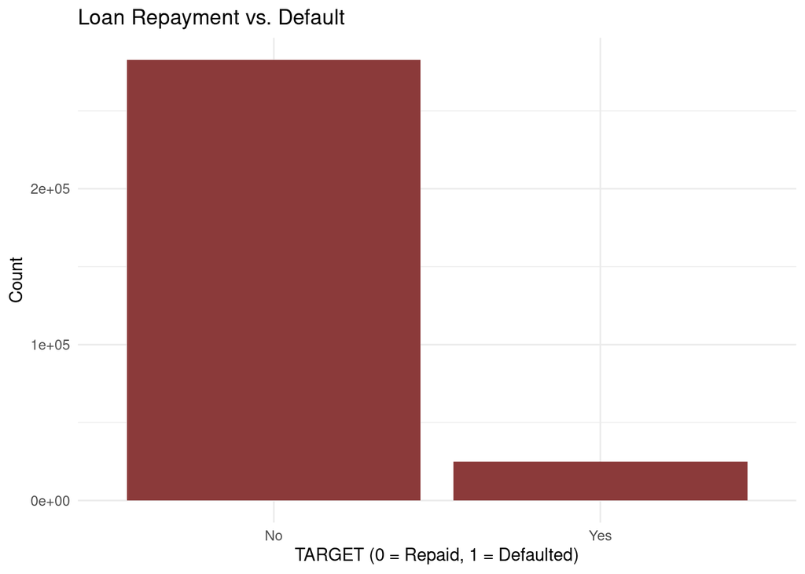

```r
# Visualize the distribution of the TARGET variable
ggplot(train, aes(x = as.factor(TARGET))) +
  geom_bar(fill = "indianred4") +
  labs(title = "Loan Repayment vs. Default", x = "TARGET (0 = Repaid, 1 = Defaulted)", y = "Count") +
  theme_minimal()
```

```r
# Majority Class Model AUC Evaluation
# Convert the TARGET variable to numeric (0 or 1) if it was previously a character or factor
target_vector <- if_else(train$TARGET == "Yes", 1, 0)

# Identify the majority class in the training set based on the target variable's distribution
majority_class <- ifelse(mean(target_vector) > 0.5, 1, 0)

# Generate predictions for the Majority Class Model (constant predictions)
majority_class_predictions <- rep(majority_class, length(train$TARGET))

# Calculate the ROC curve and AUC for the Majority Class Model
majority_class_roc <- roc(train$TARGET, as.numeric(majority_class_predictions))

# Calculate AUC for the Majority Class Model
majority_class_auc <- auc(majority_class_roc)

# Print the AUC score for the Majority Class Model
print(paste("Majority Class Model Validation AUC:", round(majority_class_auc, 3)))
```

```
## [1] "Majority Class Model Validation AUC: 0.5"
```

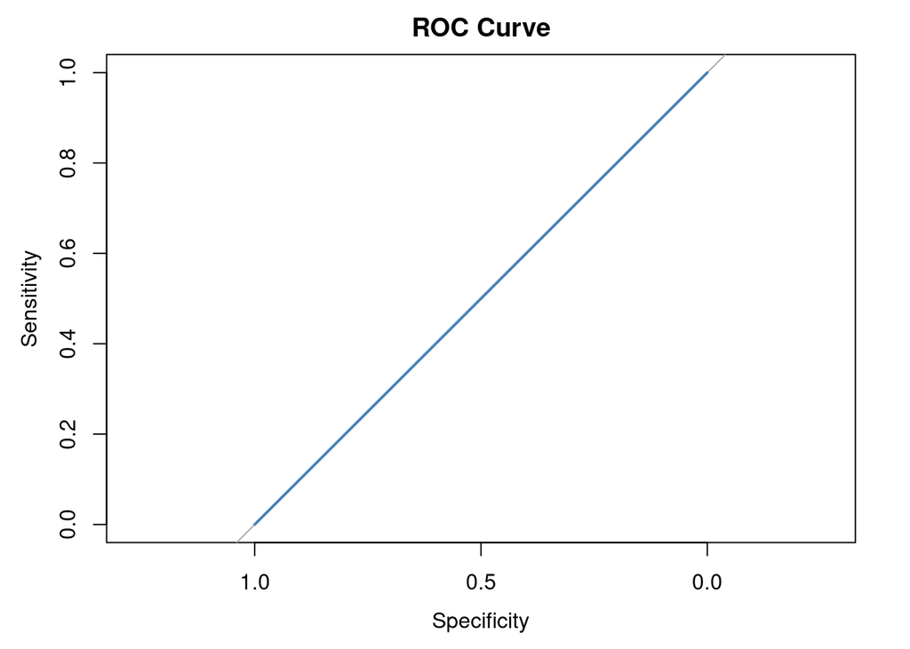

```r
plot(majority_class_roc, main="ROC Curve", col="steelblue")
```

The distribution of the target variable is highly imbalanced, with approximately 92% of the instances belonging to the “No” class and only 8% to the “Yes” class. This uneven distribution significantly affects the Majority Class Model, which predicts the majority class for all instances. The model’s validation AUC of 0.5 reflects its inability to distinguish between the two classes, indicating that it performs no better than random guessing. This model serves as our baseline, providing insight into the minimum performance we should expect. Moving forward, our goal is to create a more robust model that can effectively handle this class imbalance, capture meaningful patterns in the data, and ultimately improve the AUC score and prediction accuracy.

# Feature Selection

### Selection via XGBoost Importance

In this section, we preprocess the training data by converting the target variable into binary format and transforming categorical features into numeric values suitable for model training. Random OverSampling Examples is used to oversample the minority class to speed up traing and balance the dataset at this stage. Depending on how well these generated features turn out to be in the model assessment stage, using ROSE for the final model is a possibility. We then split the dataset into features and the target variable. Using the XGBoost model, we train on the processed data and calculate feature importance based on the Gain metric. Features with non-zero importance are identified, and the top 25 most important features are selected. Finally, we visualize the importance of these top features using a bar plot, helping to identify which features contribute most to the model’s predictions.

```r
set.seed(24601)

# Convert TARGET to binary (1 for 'Yes', 0 for 'No')
temp_train <- train %>%
  mutate(TARGET = if_else(TARGET == "Yes", 1, 0))

# Apply ROSE to balance the target variable distribution in the training set
 temp_train <- ROSE(TARGET ~ ., data = temp_train, seed = 42)$data

# Display the structure of the training set after applying ROSE
# str(temp_train)

# Check the class distribution of the target variable to verify balance
# table(temp_train$TARGET)

# Convert categorical variables to numeric format for model training
temp_train[] <- lapply(temp_train, function(x) if(is.character(x) || is.factor(x)) as.numeric(as.factor(x)) else x)

# Split the dataset into features (X) and the target variable (y)
X <- temp_train %>% select(-TARGET)
y <- temp_train$TARGET

# Ensure the target variable is numeric (0 or 1)
y <- as.numeric(y)

# Convert features to matrix format for XGBoost model
X_matrix <- as.matrix(X)

# Train the XGBoost model on the prepared dataset
dtrain <- xgb.DMatrix(data = X_matrix, label = y)
param <- list(objective = "binary:logistic", eval_metric = "auc")
xgb_model <- xgboost(
  params = param,
  data = dtrain,
  nrounds = 150,
  early_stopping_rounds = 10,
  verbose = FALSE
)

# Get the feature importance from the trained XGBoost model
importance <- xgb.importance(model = xgb_model)

# Extract features with non-zero importance based on the Gain metric
xgb_predictors <- importance$Feature[importance$Gain > 0]
xgb_predictors <- setdiff(xgb_predictors, "TARGET")

# Convert the importance matrix to a dataframe for easier handling
importance_df <- as.data.frame(importance)

# Extract a list of important features (those with non-zero Gain)
important_features <- importance$Feature[importance$Gain > 0]

# Print the important features as a vector
print(important_features)
```

```
##   [1] "AMT_INCOME_TOTAL"              "EXT_SOURCE_2"
##   [3] "AMT_BALANCE_AVG"               "EXT_SOURCE_3"
##   [5] "AMT_DRAWINGS_POS_CURRENT_SUM"  "PAYMENT_DIFFERENCE_AVG"
##   [7] "EXT_SOURCE_1"                  "AMT_ANNUITY"
##   [9] "SK_DPD_SUM"                    "NAME_EDUCATION_TYPE"
##  [11] "AMT_GOODS_PRICE"               "CNT_PAYMENT_SUM"
##  [13] "AMT_CREDIT_SUM_DEBT_SUM"       "COMMONAREA_MEDI"
##  [15] "COMMONAREA_AVG"                "DEF_30_CNT_SOCIAL_CIRCLE"
##  [17] "ELEVATORS_AVG"                 "ELEVATORS_MEDI"
##  [19] "CNT_DRAWINGS_ATM_CURRENT_SUM"  "AMT_REQ_CREDIT_BUREAU_QRT"
##  [21] "AMT_REQ_CREDIT_BUREAU_MON"     "ELEVATORS_MODE"
##  [23] "NONLIVINGAREA_AVG"             "COMMONAREA_MODE"
##  [25] "NONLIVINGAREA_MODE"            "NONLIVINGAREA_MEDI"
##  [27] "CNT_DRAWINGS_POS_CURRENT_SUM"  "AMT_CREDIT_SUM"
##  [29] "AMT_CREDIT"                    "LIVINGAREA_MEDI"
```

[output cut: 39 more lines]

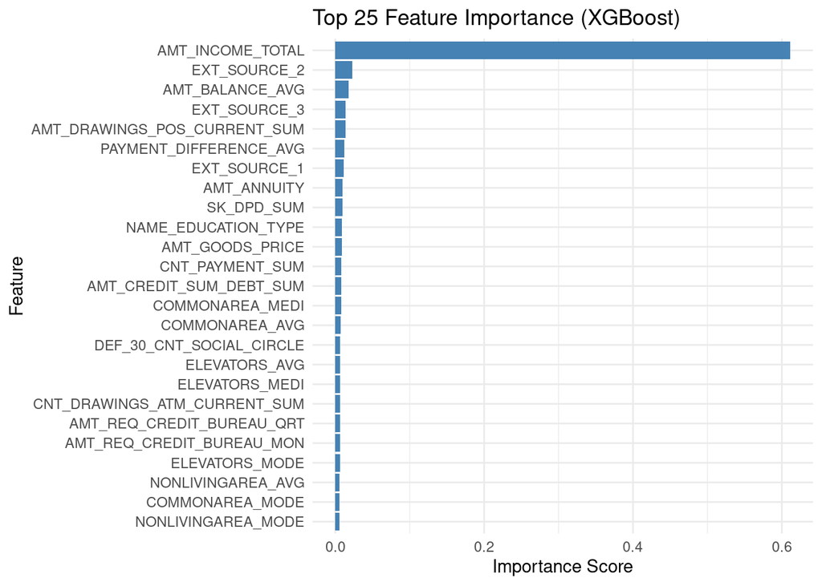

```r
# Select the top 25 features based on the Gain metric
top_features <- importance_df %>%
  arrange(desc(Gain)) %>%
  head(25)

# Plot the top 25 most important features from the XGBoost model
ggplot(top_features, aes(x = reorder(Feature, Gain), y = Gain)) +
  geom_bar(stat = "identity", fill = "steelblue") +
  coord_flip() +
  labs(title = "Top 25 Feature Importance (XGBoost)",
       x = "Feature",
       y = "Importance Score") +
  theme_minimal()
```

### Selection via Correlation and Variance

The “Feature Selection via Correlation and Variance” section focuses on optimizing the feature set for model training by eliminating redundant and irrelevant variables. It begins by identifying and removing highly correlated features, using a threshold of 0.95, to avoid multicollinearity. Next, it removes features with near-zero variance, which are unlikely to provide meaningful information for model prediction. This process helps enhance model performance by ensuring that only the most informative features are included in the analysis.

```r
# Compute correlation matrix for numeric features
numeric_features <- names(train)[sapply(train, is.numeric)]
cor_matrix <- cor(train[, numeric_features], use = "complete.obs")

# Find highly correlated features with a cutoff of 0.95
high_corr <- findCorrelation(cor_matrix, cutoff = 0.95)

# Create temporary datasets that exclude highly correlated features
temp_train <- train[, -high_corr]

# Identify near-zero variance features
nzv <- nearZeroVar(temp_train, saveMetrics = FALSE)

# Remove near-zero variance features from temporary datasets
temp_train <- temp_train[, -nzv]

# Get the remaining columns in the dataset after feature removal
corr_var_predictors <- names(temp_train)
corr_var_predictors <- setdiff(corr_var_predictors, "TARGET")

# Print the remaining columns for both train and test
print("Remaining columns in train dataset:")
```

```
## [1] "Remaining columns in train dataset:"
```

```r
print(corr_var_predictors)
```

```
##  [1] "AMT_ANNUITY"                  "AMT_ANNUITY_SUM"
##  [3] "AMT_BALANCE_AVG"              "AMT_CREDIT"
##  [5] "AMT_CREDIT_AVG"               "AMT_CREDIT_SUM_DEBT_SUM"
##  [7] "AMT_DOWN_PAYMENT_SUM"         "AMT_DRAWINGS_POS_CURRENT_SUM"
##  [9] "AMT_GOODS_PRICE_SUM"          "AMT_INCOME_TOTAL"
## [11] "AMT_PAYMENT_CURRENT_SUM"      "AMT_REQ_CREDIT_BUREAU_MON"
## [13] "AMT_REQ_CREDIT_BUREAU_QRT"    "AMT_REQ_CREDIT_BUREAU_YEAR"
## [15] "BASEMENTAREA_MODE"            "CNT_INSTALMENT_FUTURE_SUM"
## [17] "CNT_PAYMENT_SUM"              "CREDIT_ACTIVE_COUNT"
## [19] "DAYS_ID_PUBLISH"              "DAYS_INSTALMENT_AVG"
## [21] "DAYS_LAST_PHONE_CHANGE"       "DAYS_LATE_AVG"
## [23] "DAYS_REGISTRATION"            "DEF_30_CNT_SOCIAL_CIRCLE"
## [25] "ENTRANCES_MODE"               "EXT_SOURCE_1"
## [27] "EXT_SOURCE_2"                 "FLAG_OWN_CAR"
## [29] "FLAG_WORK_PHONE"              "FLOORSMAX_AVG"
## [31] "FLOORSMIN_AVG"                "FONDKAPREMONT_MODE"
## [33] "LANDAREA_AVG"                 "LANDAREA_MEDI"
## [35] "LANDAREA_MODE"                "MONTHS_BALANCE_AVG"
## [37] "NAME_CONTRACT_TYPE"           "NAME_EDUCATION_TYPE"
## [39] "NAME_HOUSING_TYPE"            "NAME_INCOME_TYPE"
## [41] "NAME_TYPE_SUITE"              "NONLIVINGAREA_AVG"
## [43] "OCCUPATION_TYPE"              "ORGANIZATION_TYPE"
## [45] "PAYMENT_DIFFERENCE_AVG"       "PREVIOUS_APPLICATIONS_COUNT"
## [47] "RATE_DOWN_PAYMENT_SUM"        "REG_CITY_NOT_WORK_CITY"
## [49] "REGION_POPULATION_RELATIVE"   "REGION_RATING_CLIENT"
## [51] "REGION_RATING_CLIENT_W_CITY"  "WALLSMATERIAL_MODE"
## [53] "WEEKDAY_APPR_PROCESS_START"
```

# Model Training and Evaluation

### Train-Vaidation Split

```r
# Set the seed for reproducibility of results
set.seed(24601)

# Convert the 'TARGET' variable from categorical ("Yes"/"No") to numeric (1/0)
train <- train %>%
  mutate(TARGET = if_else(TARGET == "Yes", 1, 0))

# Convert all categorical variables to numeric for model compatibility
train[] <- lapply(train, function(x)
  if (is.character(x) || is.factor(x))
    as.numeric(as.factor(x))
  else
    x
)

test[] <- lapply(test, function(x)
  if (is.character(x) || is.factor(x))
    as.numeric(as.factor(x))
  else
    x
)

# Split the data into training and validation sets (70% train, 30% validate)
index_train_test <- createDataPartition(train$TARGET, p = 0.7, list = FALSE)
train_set <- train[index_train_test, ]  # Training set
validate_set <- train[-index_train_test, ]  # Validation set
```

### In-Sample Training and Evaluation

```r
# Set the seed for reproducibility of results
set.seed(24601)

# Split the training set into features (X) and the target variable (y)
X <- train_set %>% select(-TARGET)
y <- train_set$TARGET

# Convert 'y' to numeric (0 or 1) if it's in a logical format
y <- as.numeric(y)

# Convert the feature matrix (X) to matrix format for XGBoost
X_matrix <- as.matrix(X)

# Train the XGBoost model on the training data
dtrain <- xgb.DMatrix(data = X_matrix, label = y)
param <- list(objective = "binary:logistic", eval_metric = "auc")
xgb_model <- xgboost(
  params = param,
  data = dtrain,
  nrounds = 150,
  early_stopping_rounds = 10,
  verbose = FALSE
)

# Predict probabilities using the XGBoost model for AUC calculation
xgb_predictions <- predict(xgb_model, X_matrix)

# Compute the AUC for the XGBoost model's predictions
xgb_roc_curve <- roc(y, xgb_predictions, quiet = TRUE)
xgb_auc_value <- auc(xgb_roc_curve)

# Print the in-sample AUC value for the XGBoost model, plot the ROC curve,
# and compute the confusion matrix to evaluate classification performance.
print(paste("In-Sample XGBoost AUC: ", round(xgb_auc_value, 4)))
```

```
## [1] "In-Sample XGBoost AUC:  0.9032"
```

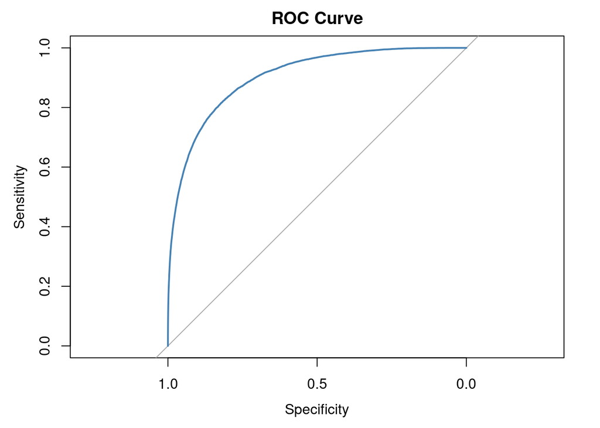

```r
plot(xgb_roc_curve, main="ROC Curve", col="steelblue")
```

```r
confusionMatrix(factor(ifelse(xgb_predictions >= 0.5, 1, 0)), factor(train_set$TARGET))
```

```
## Confusion Matrix and Statistics
##
##           Reference
## Prediction      0      1
##          0 197744  14615
##          1    286   2613
##
##                Accuracy : 0.9308
##                  95% CI : (0.9297, 0.9318)
##     No Information Rate : 0.92
##     P-Value [Acc > NIR] : < 2.2e-16
##
##                   Kappa : 0.2422
##
##  Mcnemar's Test P-Value : < 2.2e-16
##
##             Sensitivity : 0.9986
##             Specificity : 0.1517
##          Pos Pred Value : 0.9312
##          Neg Pred Value : 0.9013
##              Prevalence : 0.9200
##          Detection Rate : 0.9186
##    Detection Prevalence : 0.9865
##       Balanced Accuracy : 0.5751
##
##        'Positive' Class : 0
##
```

```r
# Train a GLM model using the XGBoost selected predictors on the full training data
xgb_glm_model <- glm(TARGET ~ ., data = train_set[, c(xgb_predictors, "TARGET")], family = binomial)

# Predict on the training set (used for in-sample evaluation)
xgb_glm_predictions <- predict(xgb_glm_model, newdata = train_set, type = "response")
xgb_gl_roc <- roc(train_set$TARGET, xgb_glm_predictions, quiet = TRUE)
xgb_gl_in_sample_auc <- auc(xgb_gl_roc)

# Print the in-sample AUC value for the XGBoost->GLM model, plot the ROC curve,
# and compute the confusion matrix to evaluate classification performance.
print(paste("In-Sample XGBoost->GLM AUC: ", round(xgb_gl_in_sample_auc, 4)))
```

```
## [1] "In-Sample XGBoost->GLM AUC:  0.7359"
```

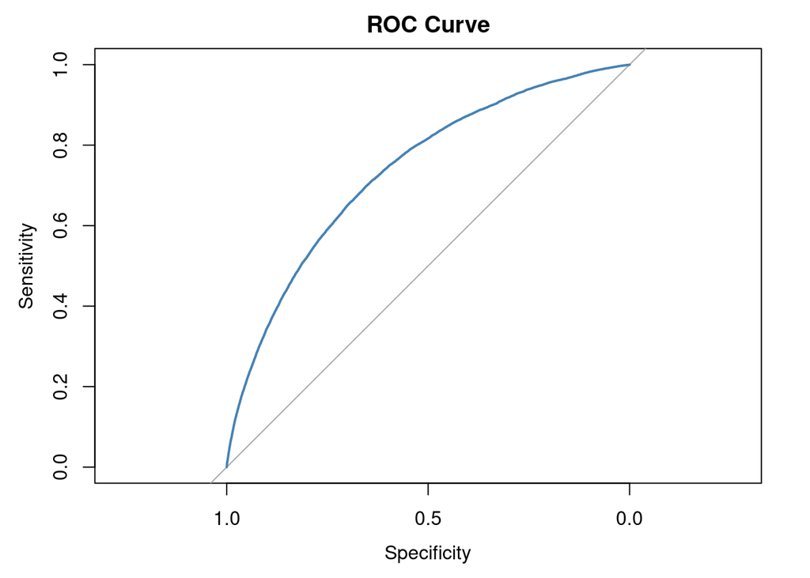

```r
plot(xgb_gl_roc, main="ROC Curve", col="steelblue")
```

```r
confusionMatrix(factor(ifelse(xgb_glm_predictions >= 0.5, 1, 0)), factor(train_set$TARGET))
```

```
## Confusion Matrix and Statistics
##
##           Reference
## Prediction      0      1
##          0 197932  17143
##          1     98     85
##
##                Accuracy : 0.9199
##                  95% CI : (0.9188, 0.921)
##     No Information Rate : 0.92
##     P-Value [Acc > NIR] : 0.5431
##
##                   Kappa : 0.0081
##
##  Mcnemar's Test P-Value : <2e-16
##
##             Sensitivity : 0.999505
##             Specificity : 0.004934
##          Pos Pred Value : 0.920293
##          Neg Pred Value : 0.464481
##              Prevalence : 0.919966
##          Detection Rate : 0.919511
##    Detection Prevalence : 0.999150
##       Balanced Accuracy : 0.502219
##
##        'Positive' Class : 0
##
```

```r
# Train a GLM model using the Variance/Correlation selected predictors on the full training data
var_corr_glm_model <- glm(TARGET ~ ., data = train_set[, c(corr_var_predictors, "TARGET")], family = binomial)

# Predict on the training set (used for in-sample evaluation)
var_corr_glm_predictions <- predict(var_corr_glm_model, newdata = train_set, type = "response")
var_corr_glm_roc <- roc(train_set$TARGET, var_corr_glm_predictions, quiet = TRUE)
var_corr_glm_in_sample_auc <- auc(var_corr_glm_roc)

# Print the in-sample AUC value for the Var/Corr model, plot the ROC curve,
# and compute the confusion matrix to evaluate classification performance.
print(paste("In-Sample Var/Corr AUC: ", round(var_corr_glm_in_sample_auc, 4)))
```

```
## [1] "In-Sample Var/Corr AUC:  0.711"
```

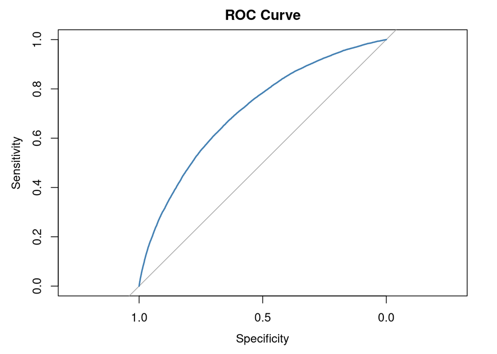

```r
plot(var_corr_glm_roc, main="ROC Curve", col="steelblue")
```

```r
confusionMatrix(factor(ifelse(var_corr_glm_predictions >= 0.5, 1, 0)), factor(train_set$TARGET))
```

```
## Confusion Matrix and Statistics
##
##           Reference
## Prediction      0      1
##          0 197961  17192
##          1     69     36
##
##                Accuracy : 0.9198
##                  95% CI : (0.9187, 0.921)
##     No Information Rate : 0.92
##     P-Value [Acc > NIR] : 0.6053
##
##                   Kappa : 0.0032
##
##  Mcnemar's Test P-Value : <2e-16
##
##             Sensitivity : 0.99965
##             Specificity : 0.00209
##          Pos Pred Value : 0.92009
##          Neg Pred Value : 0.34286
##              Prevalence : 0.91997
##          Detection Rate : 0.91965
##    Detection Prevalence : 0.99951
##       Balanced Accuracy : 0.50087
##
##        'Positive' Class : 0
##
```

##### **Conclusion:**

In the in-sample evaluation: - The **XGBoost model** significantly outperforms the other models, achieving the highest AUC and showing strong predictive power. However, its **low specificity** suggests it may overfit and misclassify defaults. - The **XGBoost->GLM model** trades off some predictive power for better generalization but still struggles to correctly classify defaults. - The **Var/Corr model** remains the weakest performer, with poor discriminatory power and minimal ability to detect defaults.

Further improvements could focus on **better feature selection, tuning decision thresholds, or exploring alternative ensemble models** to improve specificity while maintaining sensitivity.

### Out-of-Sample Evaluation

```r
# Set the seed for reproducibility of results
set.seed(24601)

# Split the validate_set into features (X) and the target variable (y)
X <- validate_set %>% select(-TARGET)
y <- validate_set$TARGET

# Convert 'y' to numeric (0 or 1) if it's logical
y <- as.numeric(y)

# Convert features to matrix format for XGBoost prediction
X_matrix <- as.matrix(X)

# Predict probabilities for the AUC calculation using the XGBoost model
xgb_predictions <- predict(xgb_model, X_matrix)

# Compute the ROC curve and AUC for the XGBoost model on the validation set
xgb_roc_curve <- roc(y, xgb_predictions, quiet = TRUE)  # Generate ROC curve
xgb_auc_value <- auc(xgb_roc_curve)

# Print the out-of-sample AUC value for the XGBoost model, plot the ROC curve,
# and compute the confusion matrix to evaluate classification performance.
print(paste("Out-of-Sample XGBoost AUC: ", round(xgb_auc_value, 4)))
```

```
## [1] "Out-of-Sample XGBoost AUC:  0.7534"
```

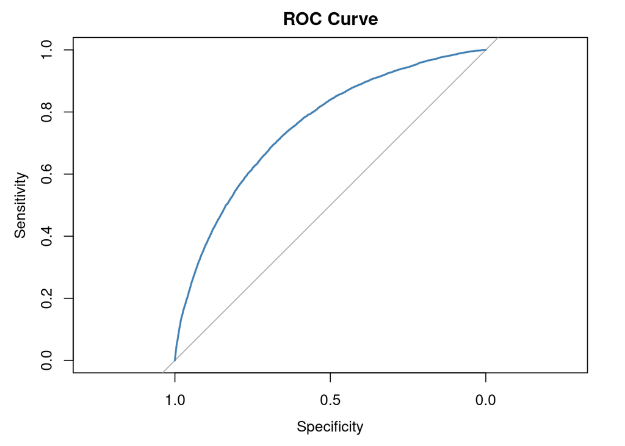

```r
plot(xgb_roc_curve, main="ROC Curve", col="steelblue")
```

```r
confusionMatrix(factor(ifelse(xgb_predictions >= 0.5, 1, 0)), factor(validate_set$TARGET))
```

```
## Confusion Matrix and Statistics
##
##           Reference
## Prediction     0     1
##          0 84228  7233
##          1   428   364
##
##                Accuracy : 0.917
##                  95% CI : (0.9152, 0.9187)
##     No Information Rate : 0.9177
##     P-Value [Acc > NIR] : 0.7803
##
##                   Kappa : 0.0724
##
##  Mcnemar's Test P-Value : <2e-16
##
##             Sensitivity : 0.99494
##             Specificity : 0.04791
##          Pos Pred Value : 0.92092
##          Neg Pred Value : 0.45960
##              Prevalence : 0.91765
##          Detection Rate : 0.91301
##    Detection Prevalence : 0.99141
##       Balanced Accuracy : 0.52143
##
##        'Positive' Class : 0
##
```

```r
# Predict on the validation set using the XGBoost->GLM model (for out-of-sample evaluation)
xgb_glm_predictions <- predict(xgb_glm_model, newdata = validate_set, type = "response")
xgb_glm_roc <- roc(validate_set$TARGET, xgb_glm_predictions, quiet = TRUE)  # Generate ROC curve
xgb_glm_out_of_sample_auc <- auc(xgb_glm_roc)

# Print the out-of-sample AUC value for the XGBoost->GLM model, plot the ROC curve,
# and compute the confusion matrix to evaluate classification performance.
print(paste("Out-of-Sample XGBoost->GLM AUC: ", round(xgb_glm_out_of_sample_auc, 4)))
```

```
## [1] "Out-of-Sample XGBoost->GLM AUC:  0.7359"
```

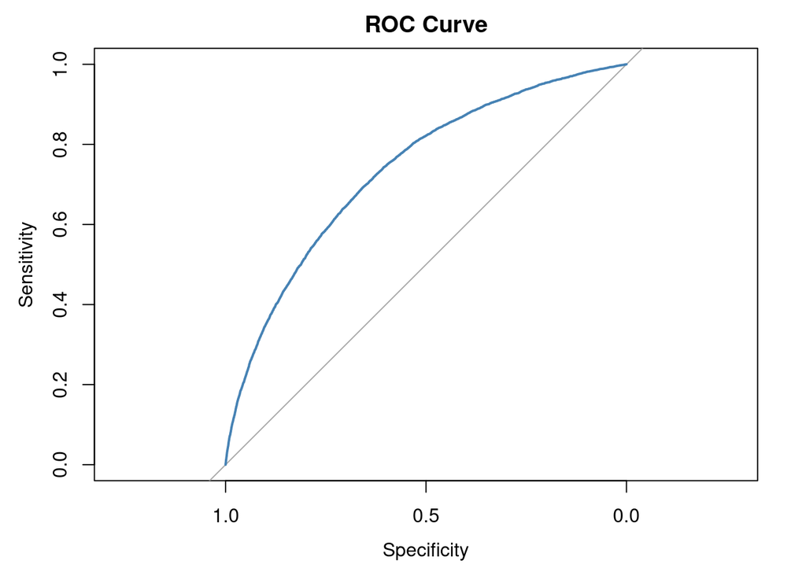

```r
plot(xgb_glm_roc, main="ROC Curve", col="steelblue")
```

```r
confusionMatrix(factor(ifelse(xgb_glm_predictions >= 0.5, 1, 0)), factor(validate_set$TARGET))
```

```
## Confusion Matrix and Statistics
##
##           Reference
## Prediction     0     1
##          0 84613  7561
##          1    43    36
##
##                Accuracy : 0.9176
##                  95% CI : (0.9158, 0.9193)
##     No Information Rate : 0.9177
##     P-Value [Acc > NIR] : 0.5364
##
##                   Kappa : 0.0077
##
##  Mcnemar's Test P-Value : <2e-16
##
##             Sensitivity : 0.999492
##             Specificity : 0.004739
##          Pos Pred Value : 0.917970
##          Neg Pred Value : 0.455696
##              Prevalence : 0.917650
##          Detection Rate : 0.917184
##    Detection Prevalence : 0.999144
##       Balanced Accuracy : 0.502115
##
##        'Positive' Class : 0
##
```

```r
# Predict on the validation set using the Var/Corr model (for out-of-sample evaluation)
var_corr_glm_predictions <- predict(var_corr_glm_model, newdata = validate_set, type = "response")
var_corr_glm_roc <- roc(validate_set$TARGET, var_corr_glm_predictions, quiet = TRUE)  # Generate ROC curve
var_corr_glm_out_of_sample_auc <- auc(var_corr_glm_roc)  # Compute AUC value

# Print the out-of-sample AUC value for the Var/Corr model, plot the ROC curve,
# and compute the confusion matrix to evaluate classification performance.
print(paste("Out-of-Sample Var/Corr AUC: ", round(var_corr_glm_out_of_sample_auc, 4)))
```

```
## [1] "Out-of-Sample Var/Corr AUC:  0.7102"
```

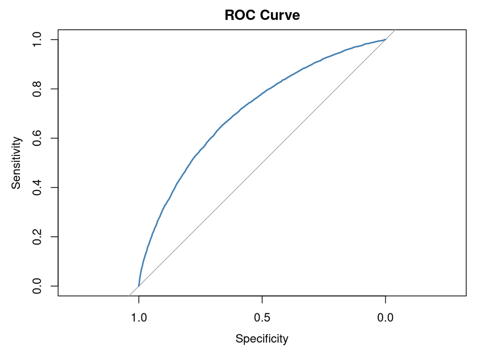

```r
plot(var_corr_glm_roc, main="ROC Curve", col="steelblue")
```

```r
confusionMatrix(factor(ifelse(var_corr_glm_predictions >= 0.5, 1, 0)), factor(validate_set$TARGET))
```

```
## Confusion Matrix and Statistics
##
##           Reference
## Prediction     0     1
##          0 84626  7568
##          1    30    29
##
##                Accuracy : 0.9176
##                  95% CI : (0.9158, 0.9194)
##     No Information Rate : 0.9177
##     P-Value [Acc > NIR] : 0.5078
##
##                   Kappa : 0.0063
##
##  Mcnemar's Test P-Value : <2e-16
##
##             Sensitivity : 0.999646
##             Specificity : 0.003817
##          Pos Pred Value : 0.917912
##          Neg Pred Value : 0.491525
##              Prevalence : 0.917650
##          Detection Rate : 0.917325
##    Detection Prevalence : 0.999360
##       Balanced Accuracy : 0.501731
##
##        'Positive' Class : 0
##
```

##### **Conclusion:**

To improve performance in real-world applications, further **model tuning, feature engineering, and threshold adjustments** are recommended to enhance default classification and generalization.

# Final Model Selection

```r
# Set the seed for reproducibility of results
set.seed(24601)

# Split the train_set into features (X) and the target variable (y)
X <- train %>% select(-TARGET)
y <- train$TARGET

# Convert 'y' to numeric (0 or 1) if it's logical
y <- as.numeric(y)

# Convert features to matrix format for XGBoost
X_matrix <- as.matrix(X)

# Train the XGBoost model using binary logistic regression and AUC as evaluation metric
dtrain <- xgb.DMatrix(data = X_matrix, label = y)  # Create DMatrix for training
param <- list(objective = "binary:logistic", eval_metric = "auc")  # Model parameters
final_model <- xgboost(
  params = param,
  data = dtrain,
  nrounds = 150,
  early_stopping_rounds = 10,
  verbose = FALSE
)

# Predict probabilities for the training set to compute AUC
final_in_sample_predictions <- predict(final_model, X_matrix)

# Compute the AUC (Area Under the Curve) for model evaluation
xgb_roc_curve <- roc(y, final_in_sample_predictions, quiet = TRUE)  # Generate ROC curve
xgb_auc_value <- auc(xgb_roc_curve)  # Compute AUC value

# Print the final AUC value for in-sample performance
print(paste("Final In-Sample XGBoost AUC: ", round(xgb_auc_value, 4)))
```

```
## [1] "Final In-Sample XGBoost AUC:  0.8803"
```

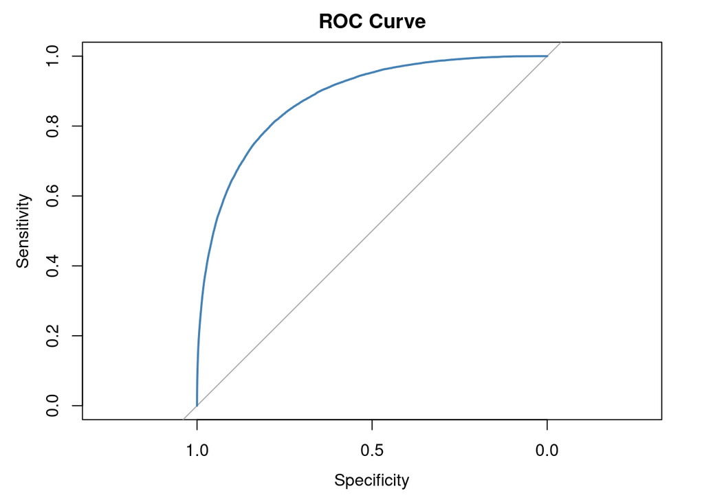

```r
plot(xgb_roc_curve, main="ROC Curve", col="steelblue")
```

### Kaggle Submission and Results

```r
# Extract the unique IDs (SK_ID_CURR) from the test set
ids <- test$SK_ID_CURR

# Prepare the feature matrix (excluding the SK_ID_CURR column)
X_matrix <- test %>%
  select(-SK_ID_CURR) %>%  # Exclude SK_ID_CURR column
  as.matrix()  # Convert to matrix format for prediction

# Get predicted probabilities from the XGBoost model (same format as glm)
xgb_predictions <- predict(final_model, X_matrix)

# Create a dataframe for the Kaggle submission with SK_ID_CURR and predicted probabilities (TARGET)
kaggle_submission <- data.frame(SK_ID_CURR = ids, TARGET = xgb_predictions)

# Print the first few rows of the submission dataframe to check the predictions
head(kaggle_submission)
```

```
##   SK_ID_CURR      TARGET
## 1     100001 0.029105913
## 2     100005 0.360111475
## 3     100013 0.009190997
## 4     100028 0.008953944
## 5     100038 0.125999779
## 6     100042 0.191312537
```

```r
# Write the submission dataframe to a CSV file (without row names)
write.csv(kaggle_submission, "kaggle_submission.csv", row.names = FALSE)
```

##### Kaggle Results

- Private Score: 0.72251
- Public Score: 0.71872

Our selected XGBoost model performed well in the Kaggle competition, achieving a Private Score of 0.72251 and a Public Score of 0.71872. The close alignment between the private and public scores suggests that the model is robust and generalizes effectively across both the competition’s training and testing datasets. The solid AUC scores indicate that our model performs well in distinguishing between default and non-default cases, with consistent performance across different sets. This reinforces the reliability of our approach for predicting loan defaults probabilities, and highlights its potential for practical use in real-world applications where similar accuracy is critical.

It is important to note that while our scores are promising, there remains potential for further refinement and enhancement of both the model and its predictive capabilities. In a professional setting, an AUC closer to 0.90 or higher would be ideal for effectively predicting loan defaults and ensuring strong model performance across diverse datasets. However, it is worth noting that the top Kaggle scores in this competition only reached around 0.80, so our performance remains competitive and demonstrates solid progress.